# lnR_metabolomics: univariate analysis

Ming Yang

Compiled: October 10, 2021

# Data description and visualization

Data dimension: 170 metabolites X 60 samples

**60 samples in total**

- 5 genotypes: wt, wt/353, 74/211, 211/19, 19/74
- 2 ages: 15d, 30d
- 3 batches: 1, 2, 3

2 replicates per genotype per age per batch

Plot two metabolite’s abundance among different genotypes and ages as examples

Metabolite abundance are log-transformed and sample-wise normalized.

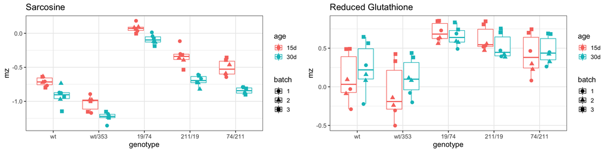

```r
dat=readRDS('./mz.filter.dat.rds')
df.mat=dat$edata;
pheno=dat$pheno

## log transform
#summary(as.numeric(unlist(df.mat))) #no zero, log directly
df.mat.log=log(df.mat)

## normalize by sample
df.scaled=scale(df.mat.log,center=T,scale=T)
#apply(df.scaled,2,mean) #confirm
#apply(df.scaled,2,sd) #confirm

## genotype explain
#wt is wildtype
#wt/353 is the ‘Mode 2’, no trade-off
#the other three are the 'Mode 1', extend lifespan by reducing costs of reproduction.
pheno$mode='mode.1';
pheno[pheno$genotype=='wt/353',]$mode='mode.2'
pheno[pheno$genotype=='wt',]$mode='wt'
#table(pheno$mode)
#mode.1 mode.2     wt
#36     12     12
genotype.levels=c('wt','wt/353','19/74','211/19','74/211');

# select two metabolites
pick.mz=c('Sarcosine','Reduced Glutathione');
df.tmp=df.scaled[pick.mz,]
plots=lapply(1:nrow(df.tmp),function(i){
    mz=df.tmp[i,]
    mz.name=rownames(df.tmp)[i]
    tmp=data.frame(mz=as.numeric(mz),age=factor(pheno$age),genotype=factor(pheno$genotype),batch=factor(pheno$batch));
    tmp$group=factor(paste(tmp$genotype,tmp$age))
    tmp$genotype=factor(tmp$genotype,levels=genotype.levels)
    ggplot(tmp,aes(x=genotype,y=mz,col=age,group=group,shape=batch))+
      geom_boxplot(outlier.shape = NA) +
      geom_jitter(size=3,position = position_jitterdodge())+
      theme_bw(base_size = 14)+ggtitle(mz.name)
  })
  do.call(grid.arrange,c(plots,ncol=2))
```

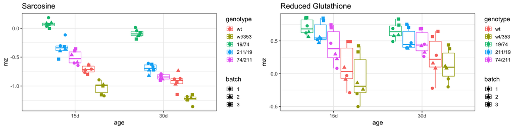

```r
plots=lapply(1:nrow(df.tmp),function(i){
    mz=df.tmp[i,]
    mz.name=rownames(df.tmp)[i]
    tmp=data.frame(mz=as.numeric(mz),age=factor(pheno$age),genotype=factor(pheno$genotype),batch=factor(pheno$batch));
    tmp$group=factor(paste(tmp$genotype,tmp$age))
    tmp$genotype=factor(tmp$genotype,levels=genotype.levels)
   ggplot(tmp,aes(x=age,y=mz,col=genotype,group=group,shape=batch))+
    geom_boxplot(outlier.shape = NA) +
    geom_jitter(size=3,position = position_jitterdodge())+
    theme_bw(base_size = 14)+ggtitle(mz.name)
  })
  do.call(grid.arrange,c(plots,ncol=2))
```

In the following analysis, I performed linear regression analysis on each metabolite to identify those metabolites with a significant `age` or `genotype` or `age:genotype interaction` effect.

# linear mixed regression on each metabolite using batch as a random effect

- I performed linear mixed regression on each metabolite using `lmer` function from the `lme4` R package:

**lmer(metabolite.abundance ~ genotype + age + genotype:age + (1|batch))**

- then used `Anova` to test the significance of each term, i.e., age, genotype, age:genotype interaction term.
- The significance, or the P value, of each term for each metabolite was adjusted using `p.adjust` function in R with the `BH` method, referred to as `p.adj`.

```r
## use batch as random effect, fit linear mixed model
#head(df.scaled)
library(lme4)
# Random intercept only
#m1 <- lmer(df.scaled[1,] ~ pheno$age + pheno$mode + pheno$mode:pheno$age + (1|pheno$batch))
# Using Anova from car to get p-values for the main effects.
#Anova(m1)


out=lapply(1:nrow(df.scaled),function(i){
  mz=df.scaled[i,]
  mz.name=rownames(df.scaled)[i] # fit model using df.res with age and mode as predictor, including interaction term
  tmp=data.frame(mz=as.numeric(mz),age=factor(pheno$age),genotype=factor(pheno$genotype),batch=factor(pheno$batch));
  tmp$genotype=factor(tmp$genotype,levels=genotype.levels)
  x=lmer(mz ~ age + genotype + genotype:age + (1|batch),data=tmp)
  x
})

# in fitting, there is message like 'boundary (singular) fit: see ?isSingular'
# may indicate over-fitting by random covariance strucutre

# use `Anova` function from the `car` R package to get p values for each factor of each mz
#Anova(out[[1]])
sig.out=lapply(out,function(x){ #make a table
  x1=car::Anova(x)
  #x1=summary(x) #this gives you coef, coef.p.value for each term
  pvalue=x1$`Pr(>Chisq)`
  #terms=rownames(x1)
  pvalue
})

df.sig.out=Reduce(`rbind`,sig.out)
x1=Anova(out[[1]])
colnames(df.sig.out)=rownames(x1)
rownames(df.sig.out)=rownames(df.scaled)
#head(df.sig.out)

df.sig.out.adj2=data.frame(matrix(p.adjust(df.sig.out,method = 'BH'),ncol=ncol(df.sig.out)))
rownames(df.sig.out.adj2)=rownames(df.sig.out)
colnames(df.sig.out.adj2)=colnames(df.sig.out)
```

After linear mixed regression, for each metabolite, there are 3 p.adj values, one for a predictor term:

```r
df.sig.out.adj2[c(rownames(df.sig.out.adj2)[1:3],pick.mz),]
```

|  | age | genotype | age:genotype |
| --- | --- | --- | --- |
| Ethanolamine | 7.423296e-01 | 1.047953e-11 | 1.370998e-01 |
| Glycine | 1.592617e-10 | 6.319960e-08 | 5.057613e-04 |
| betaAlanine | 5.825003e-11 | 2.036408e-25 | 5.243090e-06 |
| Sarcosine | 5.225908e-24 | 8.033274e-193 | 6.708344e-02 |
| Reduced Glutathione | 1.990470e-01 | 7.567324e-46 | 2.997744e-02 |

Have a look at the P.adj distributions for these three terms:

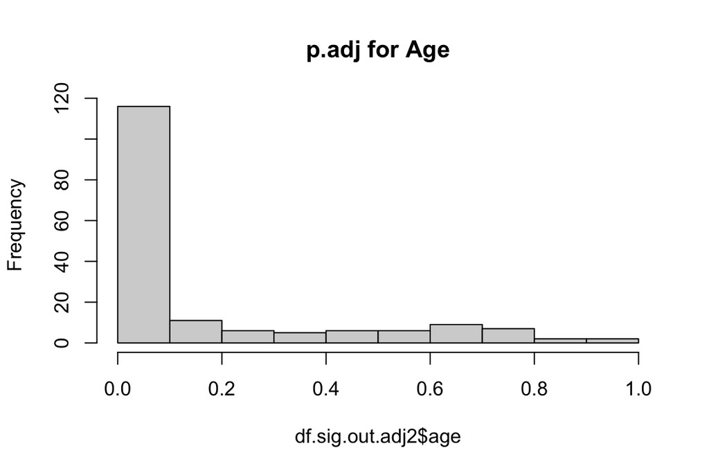

```r
hist(df.sig.out.adj2$age,main='p.adj for Age')
```

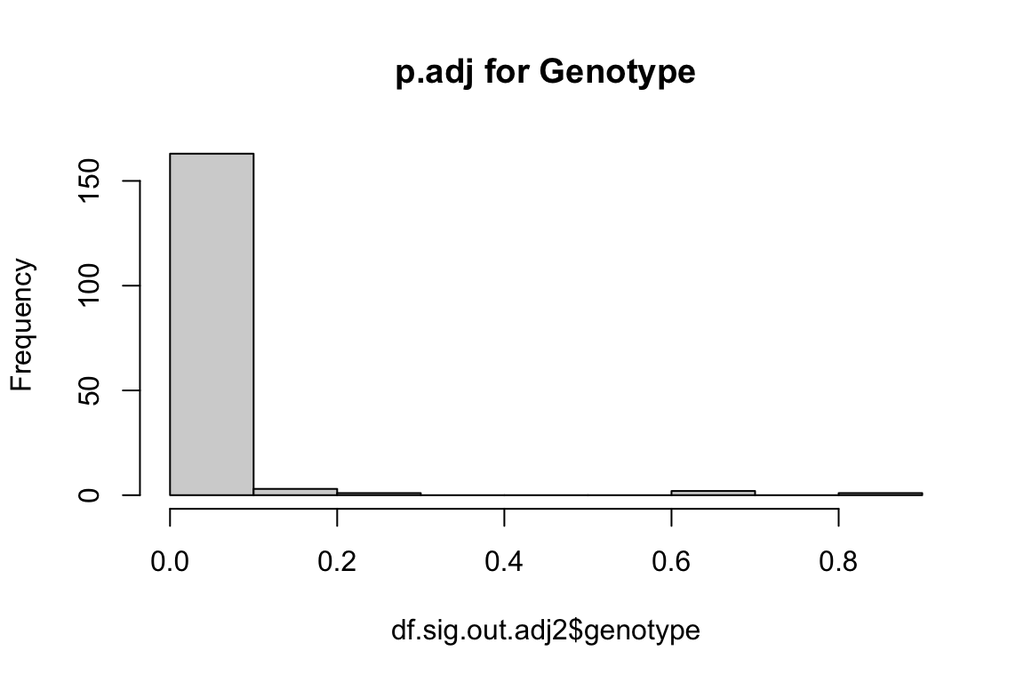

```r
hist(df.sig.out.adj2$genotype,main='p.adj for Genotype')
```

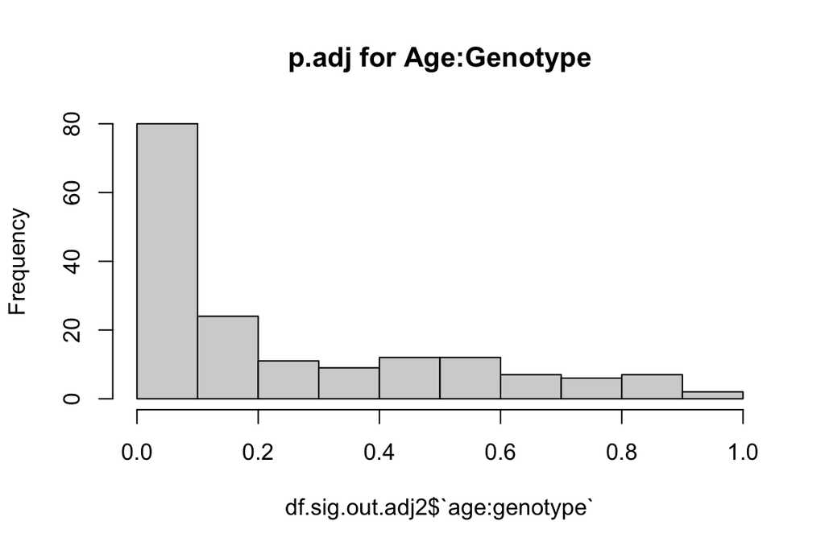

```r
hist(df.sig.out.adj2$`age:genotype`,main='p.adj for Age:Genotype')
```

For these 170 metabolites, after fitting this linear model, the number of metabolites that were significantly affected by terms at a p.adj<0.05 cutoff:

```r
#nrow(df.sig.out.adj2) #170
apply(df.sig.out.adj2,2,function(i){sum(i<0.05)})
```

```
##          age     genotype age:genotype
##          107          159           66
```

```r
#age     genotype age:genotype
#107          159           66
#rownames(df.sig.out.adj2[df.sig.out.adj2$mode<0.05,])
#df.sig.out.adj2['Sarcosine',]
```